# Visualization II

#### Visualizing Model Results

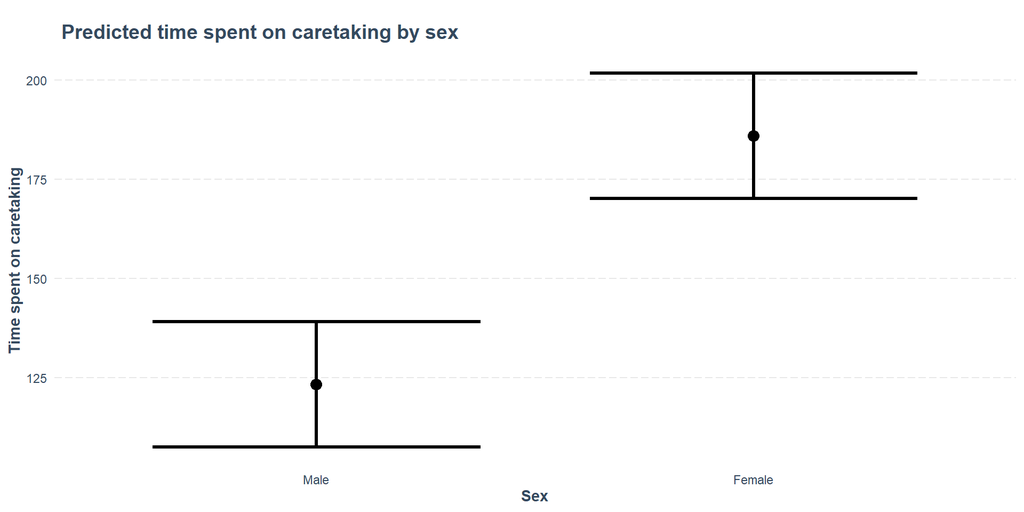

```r
effect_plot(model, pred='TESEX') +
  labs(x = "Sex",
       y = "Time spent on caretaking",
       title  ='Predicted time spent on caretaking by sex')
```

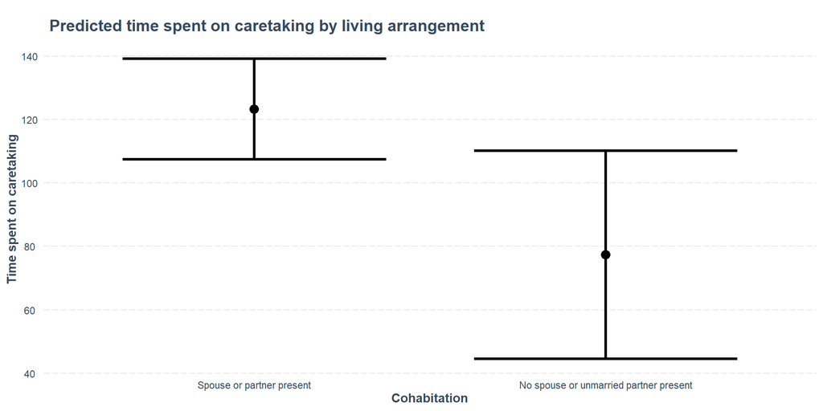

```r
effect_plot(model, pred='cohab') +
  labs(x = "Cohabitation",
       y = "Time spent on caretaking",
       title  ='Predicted time spent on caretaking by living arrangement')
```

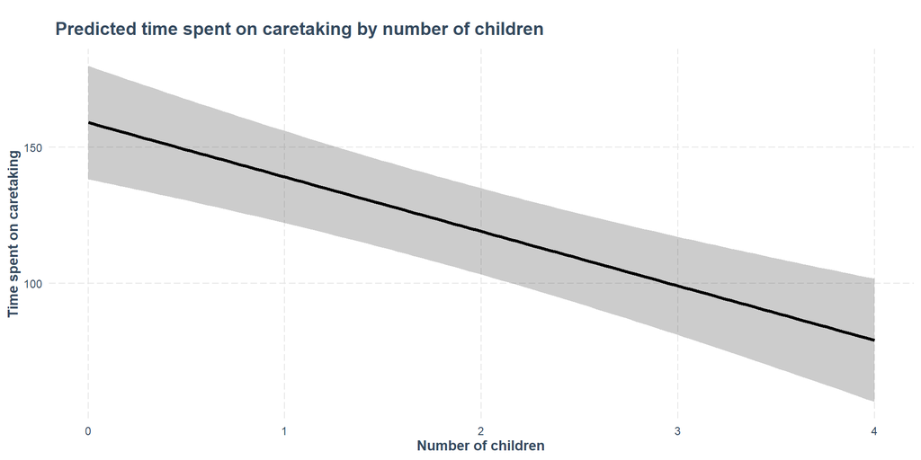

```r
effect_plot(model,
            interval = TRUE,
            pred='TRYHHCHILD') +
  labs(x = "Number of children",
       y = "Time spent on caretaking",
       title  ='Predicted time spent on caretaking by number of children')
```

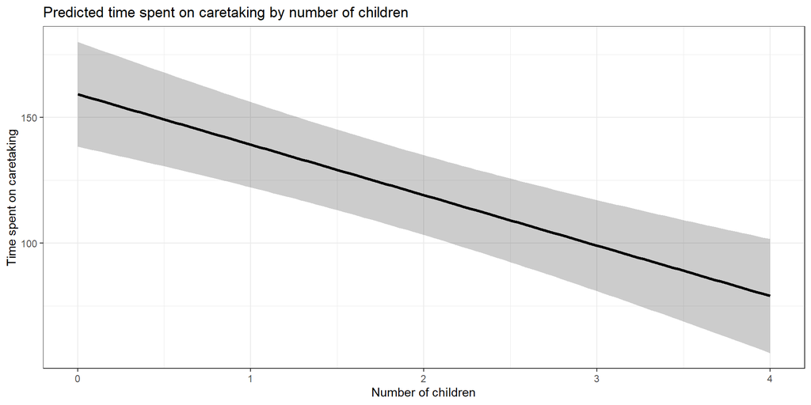

```r
effect_plot(model,
            interval = TRUE,
            pred='TRYHHCHILD') +
  labs(x = "Number of children",
       y = "Time spent on caretaking",
       title  ='Predicted time spent on caretaking by number of children') +
  theme_bw() # if you want a consistent theme, you can re-set.
```

#### Visualizing Model Results

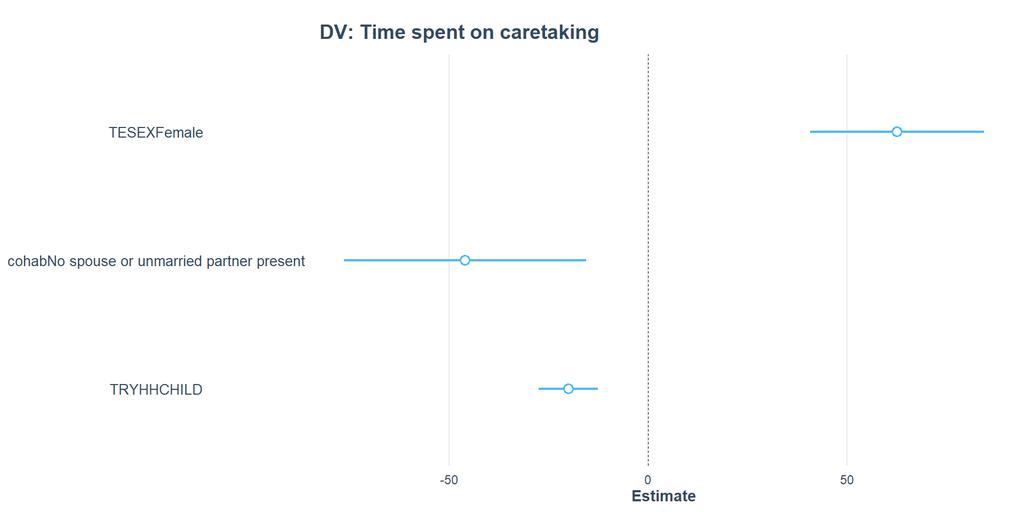

```r
plot_summs(model)+
  labs(title = "DV: Time spent on caretaking")
```

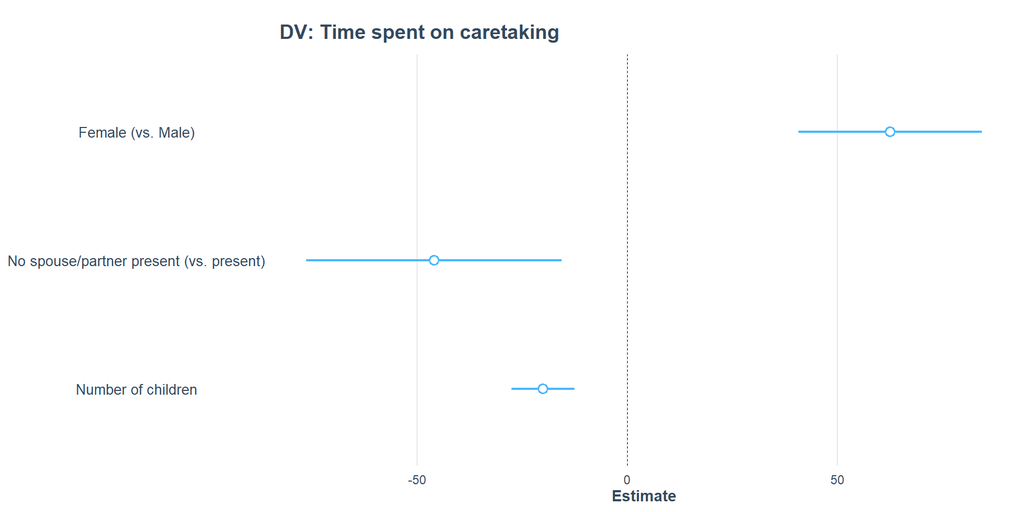

```r
plot_summs(
  model,
  coefs =  c(
    "Female (vs. Male)" = "TESEXFemale",
    "No spouse/partner present (vs. present)" = "cohabNo spouse or unmarried partner present",
    "Number of children" = "TRYHHCHILD"
  )
) +
  labs(title = "DV: Time spent on caretaking")
```

#### Visualizing Uncertainty

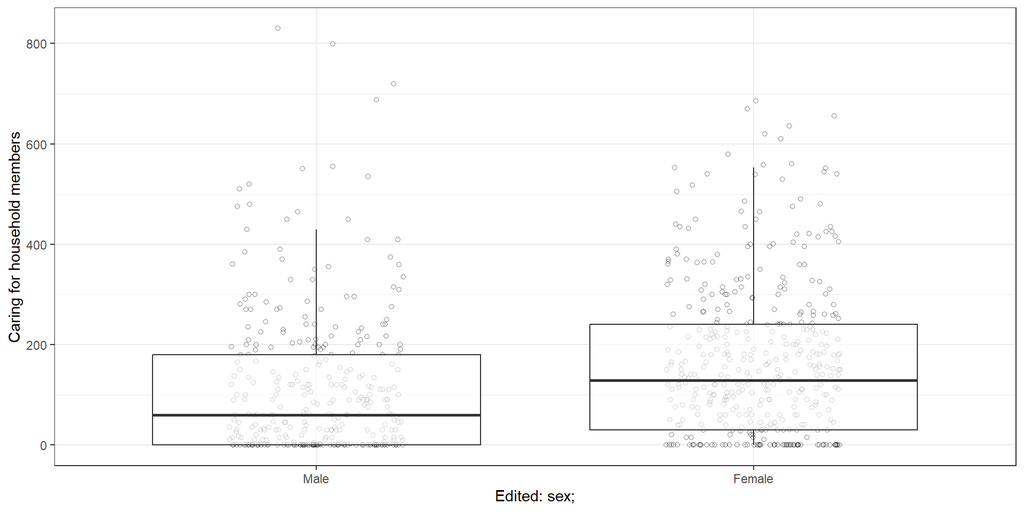

```r
atus_fmt|>
  filter(TRYHHCHILD < 5)|>
  ggplot(aes(x=TESEX, y=hh_caretaking, weight= TUFINLWGT)) +
  geom_point(position=position_jitter(width = .2), alpha=.5, pch=21) +
  geom_boxplot(outliers=FALSE , alpha=.6) +
  theme_bw()
```

## Try it out

- How does teleworking (`telework`) change the amount of time spent on `food`, `chores`, `work`, and `sports_recreation` among full time workers (`TRDPFTPT== 'Full time'`) during the weekday? Make a visual to support your argument.
- Does teleworking increase/reduce gender disparities across any of these domains?

```r
# getting the filtered data:
atus_workers<-atus_fmt|>
    filter(!TUDIARYDAY%in%c("Saturday", "Sunday"))|>
    filter(TRDPFTPT== 'Full time')|>
    drop_na(telework)
```

### General tips on data visualization

- The best way to learn is through replication: find an example and adapt it. [here’s a great place to start](https://r-graph-gallery.com/)
- Care.
- Consider resolution and audience: slide decks should have big plots with minimal detail, written reports can tolerate more subtlety.
- Almost all “3d” plots are pointless.